# glockr: An R Wrapper around Succinct Code Counter

Written in Go

Package Development

R

Author

Martin Frigaard

Published

May 24, 2026

Last week I built [`glockr`](https://mjfrigaard.github.io/glockr/), an R package that wraps scc, a “*very fast accurate code counter with complexity calculations.*” Code metrics are a fascination of mine, and now that code is increasingly written by *both* machines and humans, I wanted a set of tools I could use for comparison.

## Background

Adam Tornhill wrote two books on code metrics: [Software Design X-Rays](https://pragprog.com/titles/atevol/software-design-x-rays/) and [Your Code as a Crime Scene, 2ed](https://pragprog.com/titles/atcrime2/your-code-as-a-crime-scene-second-edition/). Both are excellent reads, and were the first exposure I had to any measurements around code complexity.[^1] The approach to metrics and data visualizations Tornhill outlines has definitely improved the way I think about writing (and maintaining code). He covers topics like essential and accidental complexity, and how often code is changed (i.e., measured via version control) is usually as important as any metrics.

The R ecosystem has some great packages for assessing code quality, too:[^2]

1. [`cloc`](https://github.com/hrbrmstr/cloc) (‘*Count Lines of Code*’) developed by [Bob Rudis](https://github.com/hrbrmstr), which wraps the ‘Perl’ command-line utility.[^3]
2. [`pkgstats`](https://docs.ropensci.org/pkgstats/index.html) is a ‘*static* code analysis tool’ from [ROpenSci](https://ropensci.org/) for R packages.
3. [Luke Tierney](https://stat.uiowa.edu/people/luke-tierney)’s [`codetools`](https://r-universe.dev/manuals/codetools.html) package also has excellent code analysis tools for R.

## What does `glockr` do?

`glockr` wraps the `scc` command-line tool in an R package (much like `cloc`). `scc` is written in pure Go, so it’s much faster than the alternatives.[^4]

Install `glockr` from GitHub:

```r
install.packages('remotes')
remotes::install_github("mjfrigaard/glockr")
```

We’ll also install `gt` and `dplyr` for data manipulation and pretty tables.

```r
install.packages(c('gt', 'dplyr'))
```

```r
library(glockr)
library(gt)
library(dplyr)
```

`glockr` computes many of the same values of the `cloc` package, but also includes the weighted complexity, unique lines of code (uloc), and Constructive Cost Model (cocomo) estimates.

Verify that `scc` is installed with:

```r
scc_version()
## [1] "scc version 3.7.0"
```

The primary function for `glockr` is `scc()`. We’ll use the popular `rlang` package as an example:[^5]

```r
pkg_path <- file.path("rlang/")
```

```r
rlang_scc <- scc(pkg_path)
dplyr::glimpse(rlang_scc)
## Rows: 11
## Columns: 10
## $ language            <chr> "R", "Markdown", "C"…
## $ files               <int> 163, 53, 70, 72, 9, …
## $ lines               <int> 44571, 16935, 14014,…
## $ code                <int> 28038, 13866, 10960,…
## $ comments            <int> 11152, 0, 872, 1777,…
## $ blanks              <int> 5381, 3069, 2182, 11…
## $ complexity          <int> 2323, 0, 1851, 691, …
## $ weighted_complexity <dbl> 8.285184, 0.000000, …
## $ bytes               <int> 1188357, 496932, 376…
## $ uloc                <int> 23837, 5358, 6931, 4…
```

The raw counts in the standard output from `scc()` includes the following columns:

1. `language`: Language of the file
2. `files`: Number of files
3. `lines`: Total physical line count across all files (code + comments + blanks)
4. `code`: Lines of source code (excludes blanks and comments)
5. `comments`: Number of total comments
6. `blanks`: Number of total blank lines
7. `bytes`: total file size in bytes across all files in that language

## Complexity & Weighted Complexity

The complexity calculation in `scc` is an *approximation* of the standard [cyclomatic complexity](https://en.wikipedia.org/wiki/Cyclomatic_complexity):[^6]

> “*The reason it’s an approximation is that it’s calculated almost for free from a CPU point of view (since its a cheap lookup when counting), whereas a real cyclomatic complexity count would need to parse the code. It gives a reasonable guess in practice though even if it fails to identify recursive methods. The goal was never for it to be exact.*

> *In short when `scc` is looking through what it has identified as code if it notices what are usually branch conditions it will increment a counter.*”

This approximation is an important limitation if your goal is to compare projects written in different languages. However, if your questions on code quality center around 1) “what are the most complex files in this project?” and – by extension – 2) “what code should be refactored?”, these metrics work well.[^7]

Below is the output from `scc()` for the `rlang` source files (sorted by `complexity`).

```r
rlang_scc |>
    dplyr::arrange(desc(complexity)) |>
    gt::gt() |>
    gt::tab_header(
      title = "Succinct Code Count (rlang package)",
      subtitle = "Sorted by complexity")
```

Succinct Code Count (rlang package)

Sorted by complexity

| language | files | lines | code | comments | blanks | complexity | weighted_complexity | bytes | uloc |
| --- | --- | --- | --- | --- | --- | --- | --- | --- | --- |
| R | 163 | 44571 | 28038 | 11152 | 5381 | 2323 | 8.285184 | 1188357 | 23837 |
| C | 70 | 14014 | 10960 | 872 | 2182 | 1851 | 16.888686 | 376444 | 6931 |
| C Header | 72 | 8210 | 5315 | 1777 | 1118 | 691 | 13.000941 | 270950 | 4809 |
| Makefile | 1 | 11 | 7 | 0 | 4 | 2 | 28.571429 | 184 | 8 |
| Markdown | 53 | 16935 | 13866 | 0 | 3069 | 0 | 0.000000 | 496932 | 5358 |
| YAML | 9 | 735 | 587 | 35 | 113 | 0 | 0.000000 | 17940 | 449 |
| C++ | 2 | 25 | 21 | 0 | 4 | 0 | 0.000000 | 492 | 17 |
| C++ Header | 1 | 26 | 21 | 0 | 5 | 0 | 0.000000 | 429 | 21 |
| SVG | 10 | 10 | 10 | 0 | 0 | 0 | 0.000000 | 9687 | 10 |
| License | 1 | 2 | 2 | 0 | 0 | 0 | 0.000000 | 43 | 2 |
| TOML | 1 | 2 | 2 | 0 | 0 | 0 | 0.000000 | 34 | 2 |

This tells us – not surprisingly – that .R code files are the most complex files in this project.

A more useful output is the most complex files in the `rlang` package, which we can do using:

```r
r_files <- scc_by_file(pkg_path, include_ext = "r")
r_files |>
  dplyr::arrange(desc(complexity)) |>
  dplyr::select(
    c(filename, code, complexity)
  ) |>
  head(10) |>
  gt::gt() |>
  gt::tab_header(
    title    = "Top 10 most complex .R files",
    subtitle = "raw branch-token count",
    preheader = "rlang package")
```

Top 10 most complex .R files

raw branch-token count

| filename | code | complexity |
| --- | --- | --- |
| cnd-abort.R | 691 | 152 |
| standalone-cli.R | 432 | 135 |
| trace.R | 807 | 134 |
| deparse.R | 819 | 111 |
| standalone-vctrs.R | 505 | 107 |
| call.R | 451 | 92 |
| standalone-obj-type.R | 206 | 64 |
| cnd-entrace.R | 213 | 61 |
| utils.R | 302 | 59 |
| expr.R | 157 | 52 |

If we compare this to the weighted complexity (`(complexity / code) * 100`), we can see a few of the top files change:

```r
r_files <- scc_by_file(pkg_path, include_ext = "r")
r_files |>
  dplyr::arrange(desc(weighted_complexity)) |>
  dplyr::select(
    c(filename, code, complexity, weighted_complexity)
  ) |>
  head(10) |>
  gt::gt() |>
  gt::tab_header(
    title    = "Top 10 most complex (weighted) .R files",
    subtitle = "Weighted Complexity",
    preheader = "rlang package")
```

Top 10 most complex (weighted) .R files

Weighted Complexity

| filename | code | complexity | weighted_complexity |
| --- | --- | --- | --- |
| operators.R | 32 | 11 | 34.37500 |
| expr.R | 157 | 52 | 33.12102 |
| standalone-cli.R | 432 | 135 | 31.25000 |
| standalone-obj-type.R | 206 | 64 | 31.06796 |
| utils-cli-tree.R | 113 | 35 | 30.97345 |
| utils-encoding.R | 37 | 11 | 29.72973 |
| cnd-entrace.R | 213 | 61 | 28.63850 |
| error-backtrace-empty.R | 16 | 4 | 25.00000 |
| raw.R | 9 | 2 | 22.22222 |
| cnd-abort.R | 691 | 152 | 21.99711 |

We won’t spend too much time on these measures, because as you’ll see below, `scc` has quite a few code metrics to choose from.

## Unique lines of code (uloc)

The unique lines of code (ULOC) counts unique non-blank lines including comments. The `scc` author argues – with help[^8] – that this is better than relying on SLOC (source lines of code):

> “*Compared to SLOC, not only are blank lines discounted, but so are close-brace lines and other repetitive code such as common includes. On the other hand, ULOC counts comments, which require just as much maintenance as the code around them does, while avoiding inflating the result with license headers which appear in every file, for example.*”

For comparison, SLOC (the value in the `code` column) is just the raw count of non-blank, non-comment lines and includes duplicates. `uloc` is automatically included with both `scc()` and `scc_by_file()`.

The best way to see the differences is with the two minimal code files:

```r
# pure code, 5 lines, two duplicate pairs
# save as code.R
x <- 1
y <- 2
x <- 1
y <- 2
z <- 3
```

```r
# same code, plus three unique comments
# save as code_w_comments.R
# step 1
x <- 1
y <- 2
# step 2
x <- 1
y <- 2
# step 3
z <- 3
```

Now we can compare these with `scc_by_file()` and view the `lines`, `code`, `comments` and `uloc` columns.

```r
fixtures <- c(
  file.path("code.R"),
  file.path("code_w_comments.R")
)
scc_by_file(fixtures) |>
  dplyr::select(c(filename, lines,
  code, comments, uloc)) |>
  gt::gt() |>
  gt::tab_header(
    title    = "SLOC vs ULOC",
    subtitle = "Both files contain the same 5 code lines",
    preheader = "Local ULOC comparison")
```

SLOC vs ULOC

Both files contain the same 5 code lines

| filename | lines | code | comments | uloc |
| --- | --- | --- | --- | --- |
| code.R | 5 | 5 | 0 | 3 |
| code_w_comments.R | 9 | 5 | 4 | 7 |

### DRYness percentage

The `DRYness %` can be added with `dryness = TRUE`. This is computed locally as `uloc / lines`, which matches scc’s `DRYness %` formula, applied per record instead of project-wide.

```r
scc_by_file(fixtures, dryness = TRUE) |>
  dplyr::select(c(filename, lines,
  code, comments, uloc, dryness)) |>
  gt::gt() |>
  gt::tab_header(
    title    = "SLOC vs ULOC + DRYness",
    subtitle = "Both files contain the same 5 code lines",
    preheader = "Local SLOC, ULOC & DRYness comparison")
```

SLOC vs ULOC + DRYness

Both files contain the same 5 code lines

| filename | lines | code | comments | uloc | dryness |
| --- | --- | --- | --- | --- | --- |
| code.R | 5 | 5 | 0 | 3 | 0.6000000 |
| code_w_comments.R | 9 | 5 | 4 | 7 | 0.7777778 |

`DRYness` values close to 1 mean a file or language is mostly unique non-blank content and values closer to 0 mean heavy duplication, comments, or blanks.

## COCOMO cost estimates

`scc` includes a [COCOMO 81](https://en.wikipedia.org/wiki/COCOMO) model that estimates project effort and cost from `SLOC`. When `cocomo = TRUE`, the `scc()` output becomes a list and the COCOMO output is in the `cocomo` tibble.

```r
rlang_cocomo <- scc(pkg_path, cocomo = TRUE)
## # A tibble: 11 × 10
##    language   files lines  code comments blanks
##    <chr>      <int> <int> <int>    <int>  <int>
##  1 R            163 44571 28038    11152   5381
##  2 Markdown      53 16935 13866        0   3069
##  3 C             70 14014 10960      872   2182
##  4 C Header      72  8210  5315     1777   1118
##  5 YAML           9   735   587       35    113
##  6 C++            2    25    21        0      4
##  7 C++ Header     1    26    21        0      5
##  8 SVG           10    10    10        0      0
##  9 Makefile       1    11     7        0      4
## 10 License        1     2     2        0      0
## 11 TOML           1     2     2        0      0
## # ℹ 4 more variables: complexity <int>,
## #   weighted_complexity <dbl>, bytes <int>,
## #   uloc <int>
## # A tibble: 3 × 3
##   metric                    project_type value
##   <chr>                     <chr>        <chr>
## 1 Estimated Cost to Develop organic      $1,948,3…
## 2 Estimated Schedule Effort organic      17.72 mo…
## 3 Estimated People Required organic      9.77
```

The `scc()` output is in the `scc` tibble:

```r
names(rlang_cocomo)
## [1] "scc"    "cocomo"
```

We can customize the COCOMO model with the following arguments:

1. `avg_wage`: annual salary in local currency
2. `cocomo_project_type`: “organic”, “semi-detached”, or “embedded”
3. `eaf`: effort adjustment factor
4. `overhead`: corporate overhead multiplier
5. `currency_symbol`: symbol shown in the value column
6. `auto_print_scc`: skip auto-printing the language tibble

**NOTE:** These arguments only work when `cocomo = TRUE`

```r
embedded <- scc(pkg_path,
    cocomo = TRUE,
    avg_wage = 120000L,
    cocomo_project_type = "embedded",
    eaf = 1.1,
    overhead = 2.0,
    currency_symbol = "$",
    auto_print_scc = FALSE)
## # A tibble: 3 × 3
##   metric                    project_type value
##   <chr>                     <chr>        <chr>
## 1 Estimated Cost to Develop embedded     $10,525,…
## 2 Estimated Schedule Effort embedded     18.57 mo…
## 3 Estimated People Required embedded     28.35
```

```r
embedded$cocomo |>
  gt::gt() |>
  gt::tab_header(
    title = "COCOMO",
    subtitle = "embedded project",
    preheader = "rlang package")
```

COCOMO

embedded project

| metric | project_type | value |
| --- | --- | --- |
| Estimated Cost to Develop | embedded | $10,525,311 |
| Estimated Schedule Effort | embedded | 18.57 months |
| Estimated People Required | embedded | 28.35 |

### Why not use COCOMO II ???

`scc()` only gives us raw structural numbers (lines, code, complexity, bytes, etc.), but [COCOMO II](https://www.rose-hulman.edu/class/cs/csse372/201310/Homework/CII_modelman2000.pdf) needs 22 judgement inputs we can’t derive from source code:

- The current COCOMO project types (`"organic"` / `"semi-detached"` / `"embedded"`) don’t translate to COCOMO II.
- COCOMO II uses 5 scale factors to esitmate organizational/process attributes
- COCOMO II also uses 17 effort multipliers for product, platform, personnel, and project context
  - Every one of these is a six-level human rating about the team, requirements stability, reuse strategy, tool maturity, schedule pressure, etc.
- The only one that *might* map would be CPLX (product complexity), but COCOMO II’s CPLX is architectural/algorithmic complexity, not McCabe’s cyclomatic.

## Visualizing code complexity

In [Your Code as a Crime Scene](https://pragprog.com/titles/atcrime2/your-code-as-a-crime-scene-second-edition/), Tornhill covers a collection of methods for visualizing code, but my favorite is his use of circle packing for identifying “hotspots.” These are described below:

> “*Each circle represents a part of the system. The more complex a module, as measured by lines of code, the larger the circle. We then use color to serve as an attention magnet for the most critical property: change.*” - Adam Tornhill (Your Code as a Crime Scene, 2ed)

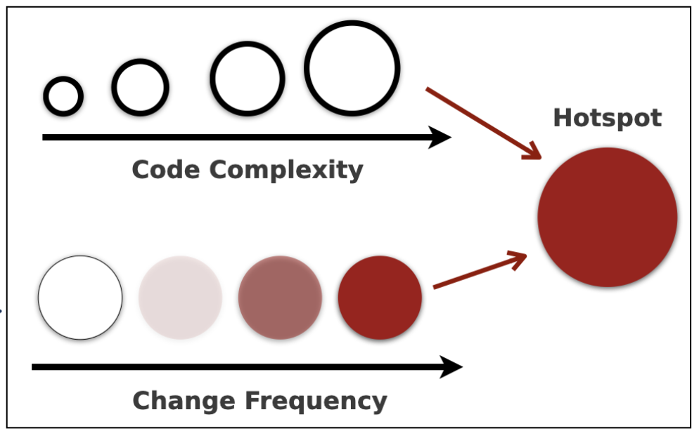

Tornhill’s Hotspots from [Your Code as a Crime Scene, 2ed](https://pragprog.com/titles/atcrime2/your-code-as-a-crime-scene-second-edition/)

The `glockr` package doesn’t have data on code changes (yet), but we can build circle packer graphs using weighted complexity and DRYness.

We’ll start by making each circle’s area tied to the file’s `weighted_complexity`, meaning the files that ‘pack more branching per line’ are larger.

Next, the color `fill` aesthetic will be the file’s DRYness % (`uloc` / `lines`), with darker hues meaning more duplication relative to line counts, and lighter hues meaning more unique, non-blank content.

We’ll start with a fresh dataset using `scc_by_file()`, setting `dryness` to `TRUE`.

```r
r_files <- scc_by_file(pkg_path, include_ext = "r", dryness = TRUE)
```

We can exclude files with zero `weighted_complexity` because there is nothing to size the circle by:

```r
r_files <- dplyr::filter(r_files, weighted_complexity > 0)
dplyr::glimpse(r_files)
## Rows: 114
## Columns: 14
## $ language            <chr> "R", "R", "R", "R", …
## $ filename            <chr> "c-lib.R", "aaa-topi…
## $ location            <chr> "/Users/mjfrigaard/p…
## $ lines               <int> 413, 93, 355, 551, 2…
## $ code                <int> 312, 65, 280, 63, 23…
## $ comments            <int> 26, 10, 12, 472, 3, …
## $ blanks              <int> 75, 18, 63, 16, 40, …
## $ complexity          <int> 21, 4, 49, 6, 5, 14,…
## $ weighted_complexity <dbl> 6.7307692, 6.1538462…
## $ bytes               <int> 9381, 2708, 10127, 1…
## $ uloc                <int> 244, 63, 227, 333, 1…
## $ dryness             <dbl> 0.5907990, 0.6774194…
## $ generated           <lgl> FALSE, FALSE, FALSE,…
## $ minified            <lgl> FALSE, FALSE, FALSE,…
```

The `packcircles::circleProgressiveLayout()` can be used to compute the area-proportional circle size:

```r
library(packcircles)
```

```r
packing <- packcircles::circleProgressiveLayout(
  r_files$weighted_complexity, sizetype = "area"
)
```

This creates a dataset with x, y, and radius columns (with the same number of observations as our previous `r_files` dataset).

```r
dplyr::glimpse(packing)
## Rows: 114
## Columns: 3
## $ x      <dbl> -1.46371800, 1.39958211, 0.052866…
## $ y      <dbl> 0.0000000, 0.0000000, -3.5102885,…
## $ radius <dbl> 1.4637180, 1.3995821, 2.3601744, …
```

The number of rows in `packing` is important, because it allows us to bind the `filename`, `weighted_complexity`, and `dryness` columns back to the `packing` data:

```r
packing <- dplyr::bind_cols(
  packing, # circle size data
  dplyr::select(r_files, # original columns
    filename, weighted_complexity, dryness)
  )
dplyr::glimpse(packing)
## Rows: 114
## Columns: 6
## $ x                   <dbl> -1.46371800, 1.39958…
## $ y                   <dbl> 0.0000000, 0.0000000…
## $ radius              <dbl> 1.4637180, 1.3995821…
## $ filename            <chr> "c-lib.R", "aaa-topi…
## $ weighted_complexity <dbl> 6.7307692, 6.1538462…
## $ dryness             <dbl> 0.5907990, 0.6774194…
```

The `circleLayoutVertices()` function from `packcircles` creates “*a data frame of circle vertices for plotting*”

```r
polygons <- packcircles::circleLayoutVertices(packing, npoints = 60)
dplyr::glimpse(polygons)
## Rows: 6,954
## Columns: 3
## $ x  <dbl> 0.00000000, -0.00801840, -0.03198575,…
## $ y  <dbl> 0.0000000, 0.1530002, 0.3043241, 0.45…
## $ id <int> 1, 1, 1, 1, 1, 1, 1, 1, 1, 1, 1, 1, 1…
```

Now we’re going to perform a positional join using the `id` from `polygons` and a new `id` we’ll create in `r_files` using `dplyr::row_number()` (and limit the columns to only `filename`, `weighted_complexity`, and `dryness`).

```r
polygons <- polygons |>
  dplyr::left_join(
    r_files |>
      dplyr::mutate(id = dplyr::row_number()) |>
      dplyr::select(
        id,
        filename,
        weighted_complexity,
        dryness),
    by = "id"
  )
dplyr::glimpse(polygons)
## Rows: 6,954
## Columns: 6
## $ x                   <dbl> 0.00000000, -0.00801…
## $ y                   <dbl> 0.0000000, 0.1530002…
## $ id                  <int> 1, 1, 1, 1, 1, 1, 1,…
## $ filename            <chr> "c-lib.R", "c-lib.R"…
## $ weighted_complexity <dbl> 6.730769, 6.730769, …
## $ dryness             <dbl> 0.590799, 0.590799, …
```

1. The `x`, `y`, and `group` aesthetics draw the circles, and `fill` is the `dryness` percentage value.
2. The [`geom_polygon()`](https://ggplot2.tidyverse.org/reference/geom_polygon.html) is used to connect start and end points (and `fill` the area inside)
3. [`scale_fill_viridis_c()`](https://ggplot2.tidyverse.org/reference/scale_viridis.html) is used for ‘filling’ continuous data, and [`coord_equal()`](https://ggplot2.tidyverse.org/reference/coord_fixed.html) ensures ensures equal unit length on the x-axis and y-axis.

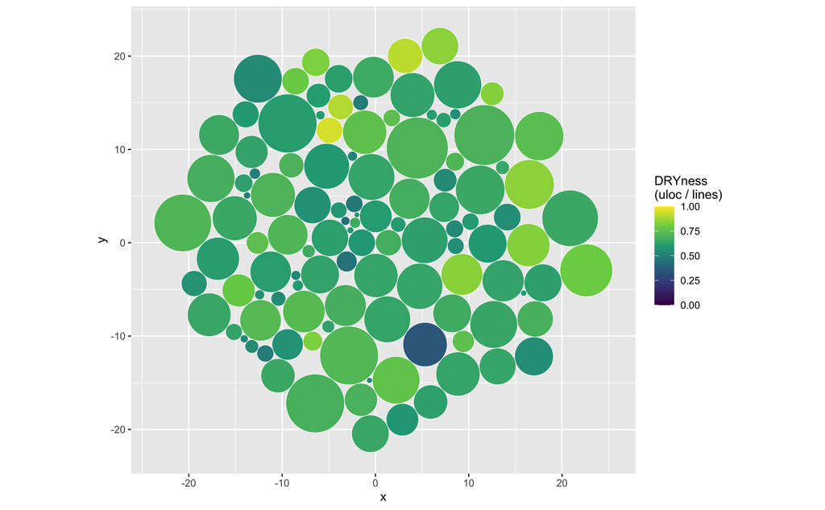

```r
ggplot2::ggplot(polygons,
                ggplot2::aes(
                  x = x,
                  y = y,
                  group = id,
                  fill = dryness)) +
  ggplot2::geom_polygon(
    colour = "white",
    linewidth = 0.2) +
  ggplot2::scale_fill_viridis_c(
    name    = "DRYness\n(uloc / lines)",
    option  = "viridis",
    limits  = c(0, 1)
  ) +
  ggplot2::coord_equal()
```

We can’t label *every* file in the circle packer graph, but we can make sure the files with the highest levels of complexity have text labels. We’ll create a `top_labels` dataset for the top 10 `weighted_complexity` values.

```r
top_labels <- packing |>
  dplyr::slice_max(weighted_complexity, n = 10)
```

```r
remotes::install_github("GuangchuangYu/shadowtext")
```

Now we can add the labels and `theme_void()`:

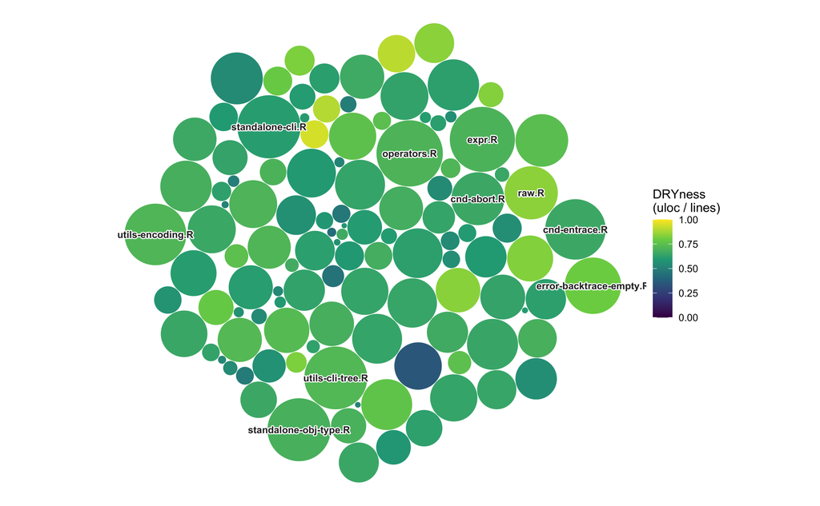

```r
# for the labels
library(shadowtext)
ggplot2::ggplot(polygons,
                ggplot2::aes(
                  x = x,
                  y = y,
                  group = id,
                  fill = dryness)) +
  ggplot2::geom_polygon(
    colour = "white",
    linewidth = 0.2) +
  # add text labels
  shadowtext::geom_shadowtext(
    data    = top_labels,
    mapping = ggplot2::aes(
      x = x,
      y = y,
      label = filename),
    inherit.aes = FALSE,
    size      = 3,
    colour    = "#2B2B2B",     # dark text
    bg.colour = "white",       # white halo so dark text stays legible
    bg.r      = 0.15,
    fontface  = "bold"
  ) +
  ggplot2::scale_fill_viridis_c(
    name    = "DRYness\n(uloc / lines)",
    option  = "viridis",
    limits  = c(0, 1)
  ) +
  ggplot2::coord_equal() +
  ggplot2::theme_void(base_size = 11)
```

This looks better. I’ll add some finishing touches with `lab()` and `theme()`:

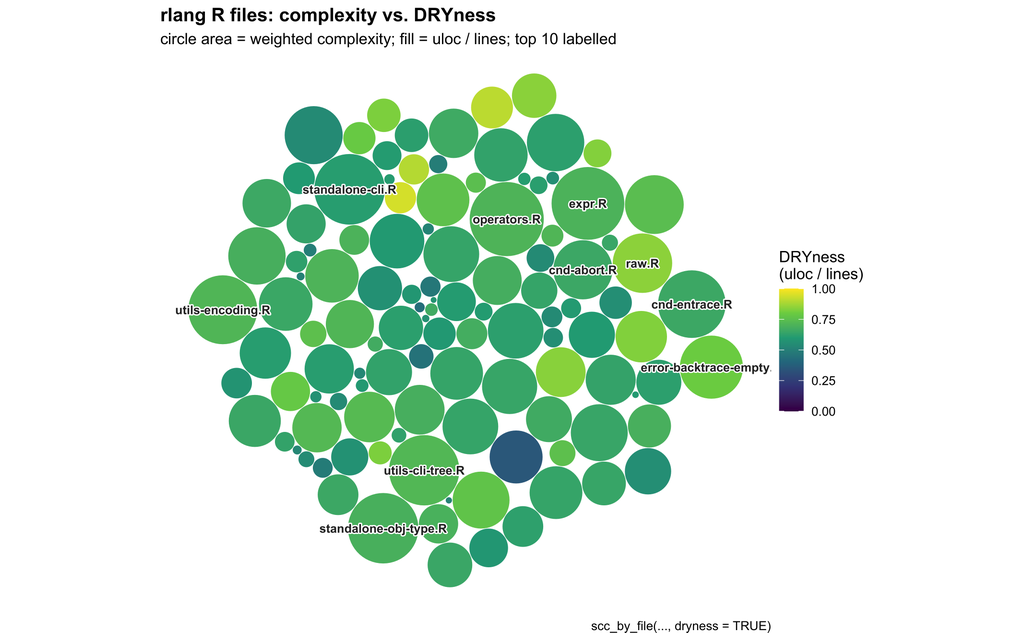

```r
# for the labels
library(shadowtext)
ggplot2::ggplot(polygons,
                ggplot2::aes(
                  x = x,
                  y = y,
                  group = id,
                  fill = dryness)) +
  ggplot2::geom_polygon(
    colour = "white",
    linewidth = 0.2) +
  # add text labels
  shadowtext::geom_shadowtext(
    data    = top_labels,
    mapping = ggplot2::aes(x = x, y = y, label = filename),
    inherit.aes = FALSE,
    size      = 3,
    colour    = "#2B2B2B",     # dark text
    bg.colour = "white",       # white halo so dark text stays legible
    bg.r      = 0.15,
    fontface  = "bold"
  ) +
  ggplot2::scale_fill_viridis_c(
    name    = "DRYness\n(uloc / lines)",
    option  = "viridis",
    limits  = c(0, 1)
  ) +
  ggplot2::coord_equal() +
  ggplot2::labs(
    title    = "rlang R files: complexity vs. DRYness",
    subtitle = "circle area = weighted complexity; fill = uloc / lines; top 10 labelled",
    x = "",
    y = "",
    caption  = "scc_by_file(..., dryness = TRUE)"
  ) +
  ggplot2::theme_void(base_size = 11) +
  ggplot2::theme(
    plot.title = ggplot2::element_text(face = "bold"),
    legend.position = "right"
  )
```

In the [Visualization vignette](https://mjfrigaard.github.io/glockr/articles/viz.html) I cover how to convert this into an interactive graph. In future versions, I’ll add the change (Git) data for more interesting hotspot visualizations.

## Footnotes

[interactive chart not shown]